# **Great Recession Impact on California Hospitals**

https://github.com/ChenxiLiD/ChenxiLiD.github.io

This is a link to the github.io site.

# **Final Tutorial: Great Recession Impact on California Hospitals**

Chenxi Li

December, 2025

## **I Introduction**

The financial crisis of 2008, often referred to as the Great Recession, severely impacted the global economy, causing massive job losses, credit freezing, and sharp drops in asset values. While the macroeconomic impacts are well-documented, I am curious how institutions such as hospitals responded to this financial disruption.

Hospitals are the cornerstones of the healthcare delivery system, falling primarily into two types: public and private. Public hospitals rely heavily on government funding, while private hospitals are typically market-driven, often operating to generate a profit.

In this project, I explore how these two types of hospitals reacted to the financial crisis using data from the California Health and Human Services Open Data Portal (*2003–2012*).

#### **Project Goal**:

In this project, I study two questions:

**Load**

The following code cell imports libraries, which are used for data management, statistical analysis, and visualization.

```python
import pandas as pd
import numpy as np
import matplotlib.pyplot as plt
import statsmodels.api as sm
import statsmodels.formula.api as s
import seaborn as sns

!pip install linearmodels
from linearmodels.panel import PanelOLS
```

[output not shown]

#### **Project Datasets**:

I am working with [Pre-2012 Hospital Annual Financial Data](https://data.chhs.ca.gov/dataset/pre-2012-hospital-annual-financial-data-selected-data-pivot-tables?__no_cache__=True) (2003-2011)and [Hospital Annual Financial Data](https://data.chhs.ca.gov/dataset/hospital-annual-financial-data-selected-data-pivot-tables) (2012)from the [California Health and Human Services Open Data Portal](https://data.chhs.ca.gov/).

This dataset contains detailed facility-level data which includs services capacity, inpatient and outpatient utilization, patient demographics, detailed revenues and expenses by type and payer, as well as the complete balance sheet and income statement of California hospitals from 2001 to 2023.

I am also working with [Pre-2012 Hospital Annual Utilization Report & Pivot Tables](https://data.chhs.ca.gov/dataset/pre-2012-hospital-annual-utilization-report-pivot-tables)(2003-2011) and [Hospital Annual Utilization Report & Pivot Tables](https://data.chhs.ca.gov/dataset/hospital-annual-utilization-report) (2012) from the [California Health and Human Services Open Data Portal](https://data.chhs.ca.gov/).

The annual hospital utilization dataset includes information on licensed beds, patient demographics such as occupancy rates, discharges, patient days, and live births, and service measures including the number of operating rooms, surgeries performed, cardiovascular procedures, and licensed emergency services.

## **II Extraction, Transform, and Load (ETL)**

**Data 1: Hospital Annual Financial Data**

I extracted the dataset.xls file from [Pre-2012 Hospital Annual Financial Data](https://data.chhs.ca.gov/dataset/pre-2012-hospital-annual-financial-data-selected-data-pivot-tables?__no_cache__=True) (2003-2011)and [Hospital Annual Financial Data](https://data.chhs.ca.gov/dataset/hospital-annual-financial-data-selected-data-pivot-tables) (2012)from the [California Health and Human Services Open Data Portal](https://data.chhs.ca.gov/).I loaded it as a Pandas dataframe. For California hospitals, this dataset includes facility numbers, facility names, location (county, address), type of control, type of care, revenues, debts, number of beds, number of visits, and other characteristic or financial variables.

Since several sheets were saved in each original xls file (profile, charts, pivot, data), I saved the datasets as separate csv files and will use them in the following analysis.

The data were imported using pandas’ read_csv() function. The table heads shown below represent the raw data before any cleaning or preprocessing.

```python
from google.colab import drive
drive.mount('/content/drive')

# Read datasets from my github
base_url = "https://raw.githubusercontent.com/ChenxiLiD/ChenxiLiD.github.io/main/"

df_2003 = pd.read_csv(base_url + "hafd2003.csv")
df_2003["year"] = 2003

df_2004 = pd.read_csv(base_url + "hafd2004.csv")
df_2004["year"] = 2004

df_2005 = pd.read_csv(base_url + "hafd2005.csv")
df_2005["year"] = 2005

df_2006 = pd.read_csv(base_url + "hafd2006.csv")
df_2006["year"] = 2006

df_2007 = pd.read_csv(base_url + "hafd2007.csv")
df_2007["year"] = 2007

df_2008 = pd.read_csv(base_url + "hafd2008.csv")
df_2008["year"] = 2008

df_2009 = pd.read_csv(base_url + "hafd2009.csv")
df_2009["year"] = 2009

df_2010 = pd.read_csv(base_url + "hafd2010.csv")
df_2010["year"] = 2010

df_2011 = pd.read_csv(base_url + "hafd2011.csv")
df_2011["year"] = 2011

df_2012 = pd.read_csv(base_url + "hafd2012.csv")
df_2012["year"] = 2012

merged_df = pd.concat([df_2003, df_2004, df_2005, df_2006, df_2007, df_2008, df_2009, df_2010, df_2011, df_2012], ignore_index=True)

merged_df = merged_df.sort_values(by=["fac_no", "year"]).reset_index(drop=True)

display(merged_df.dtypes)

merged_df.head(10)
```

|  | 0 |
| --- | --- |
| fac_no | float64 |
| fac_name | object |
| beg_date | object |
| end_date | object |
| day_per | float64 |
| ... | ... |
| allow_uncoll | float64 |
| nurs_fte | float64 |
| pd_hr_no | float64 |
| days_pips | float64 |
| curr_liab | float64 |

254 rows × 1 columns

**dtype:** object

|  | fac_no | fac_name | beg_date | end_date | day_per | data_ind | audit_ind | county | hsa | hfpa | ... | web_site | org_name | nat_births | c_sections | accts_rec | allow_uncoll | nurs_fte | pd_hr_no | days_pips | curr_liab |
| --- | --- | --- | --- | --- | --- | --- | --- | --- | --- | --- | --- | --- | --- | --- | --- | --- | --- | --- | --- | --- | --- |
| 0 | 106010735.0 | alameda hospital | 11/1/2002 | 6/30/2003 | 242.0 | audited | incl. ind. audit | alameda | 5.0 | 417.0 | ... | NaN | NaN | NaN | NaN | NaN | NaN | NaN | NaN | NaN | NaN |
| 1 | 106010735.0 | alameda hospital | 7/1/2003 | 6/30/2004 | 366.0 | audited | incl. ind. audit | alameda | 5.0 | 417.0 | ... | www.alamedahospital.org | certus corporation | 0.0 | 0.0 | 29939843.0 | -24393368.0 | 118.0 | 0.0 | NaN | NaN |
| 2 | 106010735.0 | alameda hospital | 7/1/2004 | 6/30/2005 | 365.0 | audited | incl. ind. audit | alameda | 5.0 | 417.0 | ... | www.alamedahospital.org | alameda hospital | 0.0 | 0.0 | 34697443.0 | -28653359.0 | 124.0 | 0.0 | NaN | NaN |
| 3 | 106010735.0 | alameda hospital | 7/1/2005 | 6/30/2006 | 365.0 | audited | excl. ind. audit | alameda | 5.0 | 417.0 | ... | www.alamedahospital.org | pacific hospital management | 0.0 | 0.0 | 37483775.0 | -31080095.0 | 135.0 | 0.0 | NaN | NaN |
| 4 | 106010735.0 | alameda hospital | 7/1/2006 | 6/30/2007 | 365.0 | audited | excl. ind. audit | alameda | 5.0 | 417.0 | ... | www.alamedahospital.org | pacific hospital management | 0.0 | 0.0 | 36884261.0 | -30259913.0 | 144.0 | 0.0 | NaN | NaN |
| 5 | 106010735.0 | alameda hospital | 01jul2007 | 30jun2008 | 366.0 | audited | incl. ind. audit adj. | alameda | 5.0 | 417.0 | ... | www.alamedahospital.org | pacific hospital management | 0.0 | 0.0 | 39391622.0 | -31447100.0 | 128.0 | NaN | 0.0 | 21567456.0 |
| 6 | 106010735.0 | alameda hospital | 01jul2008 | 30jun2009 | 365.0 | audited | incl. ind. audit adj. | alameda | 5.0 | 417.0 | ... | alamedahospital.org | pacific hospital management | 0.0 | 0.0 | 45456036.0 | -35386500.0 | 159.0 | NaN | 0.0 | 17993828.0 |
| 7 | 106010735.0 | alameda hospital | 01jul2009 | 30jun2010 | 365.0 | audited | incl. ind. audit adj. | alameda | 5.0 | 417.0 | ... | www.alamedahospital.org | pacific hospital management | 0.0 | 0.0 | 43504333.0 | -33946186.0 | 161.0 | NaN | 0.0 | 17796961.0 |
| 8 | 106010735.0 | alameda hospital | 01jul2010 | 30jun2011 | 365.0 | audited | incl. ind. audit adj. | alameda | 5.0 | 417.0 | ... | www.alamedahospital.org | pacific hospital management | 0.0 | 0.0 | 35446216.0 | -28197031.0 | 149.0 | NaN | 0.0 | 17750199.0 |
| 9 | 106010735.0 | alameda hospital | 01jul2011 | 30jun2012 | 366.0 | audited | incl. ind. audit adj. | alameda | 5.0 | 417.0 | ... | www.alamedahospital.org | pacific hospital management | 0.0 | 0.0 | 52325882.0 | -43490626.0 | 147.0 | NaN | 0.0 | 20749426.0 |

10 rows × 254 columns

As shown above, the ten datasets have been combined into a single dataset. Since some NaN values remain, we next load the remaining datasets, merge them with the current dataset, and then check whether the missing values persist.

### **Data 2: Hospital Annual Utility Data**

I extracted the dataset.xls file from [Pre-2012 Hospital Annual Utilization Report & Pivot Tables](https://data.chhs.ca.gov/dataset/pre-2012-hospital-annual-utilization-report-pivot-tables)(2003-2011) and [Hospital Annual Utilization Report & Pivot Tables](https://data.chhs.ca.gov/dataset/hospital-annual-utilization-report) (2012) from the [California Health and Human Services Open Data Portal](https://data.chhs.ca.gov/).

Since several sheets were saved in each original xls file (profile, charts, pivot, data), I saved the datasets as separate csv files and will use them in the following analysis.

```python
base_url = "https://raw.githubusercontent.com/ChenxiLiD/ChenxiLiD.github.io/main/"

df_util_2003 = pd.read_csv(base_url + "2003.csv")
df_util_2003["year"] = 2003

df_util_2004 = pd.read_csv(base_url + "2004.csv")
df_util_2004["year"] = 2004

df_util_2005 = pd.read_csv(base_url + "2005.csv")
df_util_2005["year"] = 2005

df_util_2006 = pd.read_csv(base_url + "2006.csv")
df_util_2006["year"] = 2006

df_util_2007 = pd.read_csv(base_url + "2007.csv")
df_util_2007["year"] = 2007

df_util_2008 = pd.read_csv(base_url + "2008.csv")
df_util_2008["year"] = 2008

df_util_2009 = pd.read_csv(base_url + "2009.csv")
df_util_2009["year"] = 2009

df_util_2010 = pd.read_csv(base_url + "2010.csv")
df_util_2010["year"] = 2010

df_util_2011 = pd.read_csv(base_url + "2011.csv")
df_util_2011["year"] = 2011

df_util_2012 = pd.read_csv(base_url + "2012.csv")
df_util_2012["year"] = 2012


merged_util_df = pd.concat([df_util_2003, df_util_2004, df_util_2005, df_util_2006, df_util_2007, df_util_2008, df_util_2009, df_util_2010, df_util_2011, df_util_2012], ignore_index=True)


merged_util_df = merged_util_df.sort_values(by=["OSHPD_ID", "year"]).reset_index(drop=True)


display(merged_util_df.dtypes)

merged_util_df.head(10)
```

|  | 0 |
| --- | --- |
| OSHPD_ID | float64 |
| FAC_NAME | object |
| BEG_DATE | object |
| END_DATE | object |
| LIC_STATUS | object |
| ... | ... |
| HSP_IP_Pal_CARE_PROG_PHYSICIAN | float64 |
| HSP_IP_Pal_CARE_PROG_PHYSICIAN_C | float64 |
| HSP_IP_Pal_CARE_PROG_SOCIAL_WORK | float64 |
| HSP_IP_Pal_CARE_PROG_CHAPLAINS | float64 |
| HSP_OUTPATIENT_PAL_CARE_SERV_OFF | object |

396 rows × 1 columns

**dtype:** object

|  | OSHPD_ID | FAC_NAME | BEG_DATE | END_DATE | LIC_STATUS | LIC_STATUS_DATE | LIC_ORIG_DATE | County Name | HEALTH_SVC_AREA | LIC_CAT | ... | DX_EP_STUDY | OTHR_CATH_PROC | HSP_IP_Pal_CARE_PROG_OFFERED | HSP_IP_Pal_CARE_PROG_NURSES | HSP_IP_Pal_CARE_PROG_NURSES_CERT | HSP_IP_Pal_CARE_PROG_PHYSICIAN | HSP_IP_Pal_CARE_PROG_PHYSICIAN_C | HSP_IP_Pal_CARE_PROG_SOCIAL_WORK | HSP_IP_Pal_CARE_PROG_CHAPLAINS | HSP_OUTPATIENT_PAL_CARE_SERV_OFF |
| --- | --- | --- | --- | --- | --- | --- | --- | --- | --- | --- | --- | --- | --- | --- | --- | --- | --- | --- | --- | --- | --- |
| 0 | 106010735.0 | ALAMEDA HOSPITAL | 1/1/03 | 12/31/03 | Licensed | NaN | January 1, 1946 | Alameda | 05 - East Bay | General Acute Care | ... | NaN | NaN | NaN | NaN | NaN | NaN | NaN | NaN | NaN | NaN |
| 1 | 106010735.0 | ALAMEDA HOSPITAL | 1/1/04 | 12/31/04 | Open | 1/1/46 | 1/1/46 | Alameda | 05 - East Bay | General Acute Care | ... | NaN | NaN | NaN | NaN | NaN | NaN | NaN | NaN | NaN | NaN |
| 2 | 106010735.0 | ALAMEDA HOSPITAL | 1/1/05 | 12/31/05 | Open | 1/1/46 | 1/1/46 | Alameda | 05 - East Bay | General Acute Care | ... | NaN | NaN | NaN | NaN | NaN | NaN | NaN | NaN | NaN | NaN |
| 3 | 106010735.0 | ALAMEDA HOSPITAL | 1/1/06 | 12/31/06 | Open | 1/1/46 | 1/1/46 | Alameda | 05 - East Bay | General Acute Care | ... | NaN | NaN | NaN | NaN | NaN | NaN | NaN | NaN | NaN | NaN |
| 4 | 106010735.0 | ALAMEDA HOSPITAL | 1/1/07 | 12/31/07 | Open | NaN | 1/1/46 | NaN | 05 - East Bay | General Acute Care | ... | NaN | NaN | NaN | NaN | NaN | NaN | NaN | NaN | NaN | NaN |
| 5 | 106010735.0 | ALAMEDA HOSPITAL | 01/01/2008 | 12/31/2008 | Open | 01/01/1946 | 01/01/1946 | NaN | 05 - East Bay | General Acute Care | ... | NaN | NaN | NaN | NaN | NaN | NaN | NaN | NaN | NaN | NaN |
| 6 | 106010735.0 | ALAMEDA HOSPITAL | 01/01/2009 | 12/31/2009 | Open | 01/01/1946 | 01/01/1946 | NaN | 05 - East Bay | General Acute Care | ... | NaN | NaN | NaN | NaN | NaN | NaN | NaN | NaN | NaN | NaN |
| 7 | 106010735.0 | ALAMEDA HOSPITAL | 01Jan2010 | 31Dec2010 | Open | 01Jan1946 | 01Jan1946 | NaN | 05 - East Bay | General Acute Care | ... | NaN | NaN | NaN | NaN | NaN | NaN | NaN | NaN | NaN | NaN |
| 8 | 106010735.0 | ALAMEDA HOSPITAL | 01/01/2011 | 12/31/2011 | Open | 01/01/1946 | 01/01/1946 | NaN | 05 - East Bay | General Acute Care | ... | NaN | NaN | NaN | NaN | NaN | NaN | NaN | NaN | NaN | NaN |
| 9 | 106010735.0 | ALAMEDA HOSPITAL | 01/01/2012 | 12/31/2012 | Open | 01/01/1946 | 01/01/1946 | NaN | 05 - East Bay | General Acute Care | ... | 0.0 | 0.0 | No | 0.0 | 0.0 | 0.0 | 0.0 | 0.0 | 0.0 | No |

10 rows × 396 columns

Similar to the first dataset, some NaN values are present in this dataset. We will merge the two combined datasets and drop the NaN values.

### **Combining two Datasets**

The key that connects the two datasets is facility number， which is called "fac_no" in the financial data and "OSHPD_ID" in the utility data.

Next, I will rename the "OSHPD_ID" to "fac_no" then use this key to merge two datasets.

The outer merge returns all rows from both DataFrames, and fills in NaN for cells where there is no matching data in the other DataFrame.

```python
merged_util_df = merged_util_df.rename(columns={'OSHPD_ID': 'fac_no'})

final_merged_df = pd.merge(merged_df, merged_util_df, on=['fac_no', 'year'], how='outer')
display(final_merged_df.head(20))
```

|  | fac_no | fac_name | beg_date | end_date | day_per | data_ind | audit_ind | county | hsa | hfpa | ... | DX_EP_STUDY | OTHR_CATH_PROC | HSP_IP_Pal_CARE_PROG_OFFERED | HSP_IP_Pal_CARE_PROG_NURSES | HSP_IP_Pal_CARE_PROG_NURSES_CERT | HSP_IP_Pal_CARE_PROG_PHYSICIAN | HSP_IP_Pal_CARE_PROG_PHYSICIAN_C | HSP_IP_Pal_CARE_PROG_SOCIAL_WORK | HSP_IP_Pal_CARE_PROG_CHAPLAINS | HSP_OUTPATIENT_PAL_CARE_SERV_OFF |
| --- | --- | --- | --- | --- | --- | --- | --- | --- | --- | --- | --- | --- | --- | --- | --- | --- | --- | --- | --- | --- | --- |
| 0 | 106010735.0 | alameda hospital | 11/1/2002 | 6/30/2003 | 242.0 | audited | incl. ind. audit | alameda | 5.0 | 417.0 | ... | NaN | NaN | NaN | NaN | NaN | NaN | NaN | NaN | NaN | NaN |
| 1 | 106010735.0 | alameda hospital | 7/1/2003 | 6/30/2004 | 366.0 | audited | incl. ind. audit | alameda | 5.0 | 417.0 | ... | NaN | NaN | NaN | NaN | NaN | NaN | NaN | NaN | NaN | NaN |
| 2 | 106010735.0 | alameda hospital | 7/1/2004 | 6/30/2005 | 365.0 | audited | incl. ind. audit | alameda | 5.0 | 417.0 | ... | NaN | NaN | NaN | NaN | NaN | NaN | NaN | NaN | NaN | NaN |
| 3 | 106010735.0 | alameda hospital | 7/1/2005 | 6/30/2006 | 365.0 | audited | excl. ind. audit | alameda | 5.0 | 417.0 | ... | NaN | NaN | NaN | NaN | NaN | NaN | NaN | NaN | NaN | NaN |
| 4 | 106010735.0 | alameda hospital | 7/1/2006 | 6/30/2007 | 365.0 | audited | excl. ind. audit | alameda | 5.0 | 417.0 | ... | NaN | NaN | NaN | NaN | NaN | NaN | NaN | NaN | NaN | NaN |
| 5 | 106010735.0 | alameda hospital | 01jul2007 | 30jun2008 | 366.0 | audited | incl. ind. audit adj. | alameda | 5.0 | 417.0 | ... | NaN | NaN | NaN | NaN | NaN | NaN | NaN | NaN | NaN | NaN |
| 6 | 106010735.0 | alameda hospital | 01jul2008 | 30jun2009 | 365.0 | audited | incl. ind. audit adj. | alameda | 5.0 | 417.0 | ... | NaN | NaN | NaN | NaN | NaN | NaN | NaN | NaN | NaN | NaN |
| 7 | 106010735.0 | alameda hospital | 01jul2009 | 30jun2010 | 365.0 | audited | incl. ind. audit adj. | alameda | 5.0 | 417.0 | ... | NaN | NaN | NaN | NaN | NaN | NaN | NaN | NaN | NaN | NaN |
| 8 | 106010735.0 | alameda hospital | 01jul2010 | 30jun2011 | 365.0 | audited | incl. ind. audit adj. | alameda | 5.0 | 417.0 | ... | NaN | NaN | NaN | NaN | NaN | NaN | NaN | NaN | NaN | NaN |
| 9 | 106010735.0 | alameda hospital | 01jul2011 | 30jun2012 | 366.0 | audited | incl. ind. audit adj. | alameda | 5.0 | 417.0 | ... | 0.0 | 0.0 | No | 0.0 | 0.0 | 0.0 | 0.0 | 0.0 | 0.0 | No |
| 10 | 106010739.0 | alta bates summit med ctr-alta bates cam | 1/1/2003 | 12/31/2003 | 365.0 | audited | incl. ind. audit | alameda | 5.0 | 415.0 | ... | NaN | NaN | NaN | NaN | NaN | NaN | NaN | NaN | NaN | NaN |
| 11 | 106010739.0 | alta bates summit med ctr-alta bates cam | 1/1/2004 | 12/31/2004 | 366.0 | audited | incl. ind. audit | alameda | 5.0 | 415.0 | ... | NaN | NaN | NaN | NaN | NaN | NaN | NaN | NaN | NaN | NaN |
| 12 | 106010739.0 | alta bates summit med ctr-alta bates campus | 1/1/2005 | 12/31/2005 | 365.0 | audited | incl. ind. audit | alameda | 5.0 | 415.0 | ... | NaN | NaN | NaN | NaN | NaN | NaN | NaN | NaN | NaN | NaN |
| 13 | 106010739.0 | alta bates summit med ctr-alta bates campus | 1/1/2006 | 12/31/2006 | 365.0 | audited | incl. ind. audit | alameda | 5.0 | 415.0 | ... | NaN | NaN | NaN | NaN | NaN | NaN | NaN | NaN | NaN | NaN |
| 14 | 106010739.0 | alta bates summit med ctr-alta bates campus | 1/1/2007 | 12/31/2007 | 365.0 | audited | incl. ind. audit | alameda | 5.0 | 415.0 | ... | NaN | NaN | NaN | NaN | NaN | NaN | NaN | NaN | NaN | NaN |
| 15 | 106010739.0 | alta bates summit med ctr-alta bates campus | 01jan2008 | 31dec2008 | 366.0 | audited | incl. ind. audit adj. | alameda | 5.0 | 415.0 | ... | NaN | NaN | NaN | NaN | NaN | NaN | NaN | NaN | NaN | NaN |
| 16 | 106010739.0 | alta bates summit med ctr-alta bates campus | 01jan2009 | 31dec2009 | 365.0 | audited | incl. ind. audit adj. | alameda | 5.0 | 415.0 | ... | NaN | NaN | NaN | NaN | NaN | NaN | NaN | NaN | NaN | NaN |
| 17 | 106010739.0 | alta bates summit med ctr-alta bates campus | 01jan2010 | 31dec2010 | 365.0 | audited | incl. ind. audit adj. | alameda | 5.0 | 415.0 | ... | NaN | NaN | NaN | NaN | NaN | NaN | NaN | NaN | NaN | NaN |
| 18 | 106010739.0 | alta bates summit med ctr-alta bates campus | 01jan2011 | 31dec2011 | 365.0 | audited | incl. ind. audit adj. | alameda | 5.0 | 415.0 | ... | NaN | NaN | NaN | NaN | NaN | NaN | NaN | NaN | NaN | NaN |
| 19 | 106010739.0 | alta bates summit med ctr-alta bates campus | 01jan2012 | 31dec2012 | 366.0 | audited | incl. ind. audit adj. | alameda | 5.0 | 415.0 | ... | 4.0 | 0.0 | Yes | 1.0 | 1.0 | 2.0 | 2.0 | 2.0 | 2.0 | No |

20 rows × 648 columns

I keep only the necessary columns and drop all others. I then reorder the variables to make the dataset more organized and easier to follow, using the sequence:

fac_no, fac_name, county, year, net_pt_rev, dis_tot, bed_lic, bed_avl, hosp_fte.

```python
keep_cols = ['net_pt_rev', 'type_cntrl', 'dis_tot', 'bed_lic', 'bed_avl', 'fac_no', 'fac_name', 'county', 'year', 'hosp_fte']

new_column_order = [
    'fac_no', 'fac_name', 'type_cntrl','county', 'year',
    'net_pt_rev', 'dis_tot', 'bed_lic', 'bed_avl', 'hosp_fte'
]

final_merged_df = final_merged_df[new_column_order].copy()

display(final_merged_df.head(10))
```

|  | fac_no | fac_name | type_cntrl | county | year | net_pt_rev | dis_tot | bed_lic | bed_avl | hosp_fte |
| --- | --- | --- | --- | --- | --- | --- | --- | --- | --- | --- |
| 0 | 106010735.0 | alameda hospital | district | alameda | 2003 | 27478784.0 | 2188.0 | 135.0 | 135.0 | 359.0 |
| 1 | 106010735.0 | alameda hospital | district | alameda | 2004 | 38474674.0 | 3038.0 | 135.0 | 135.0 | 382.0 |
| 2 | 106010735.0 | alameda hospital | district | alameda | 2005 | 44498250.0 | 3096.0 | 135.0 | 135.0 | 370.0 |
| 3 | 106010735.0 | alameda hospital | district | alameda | 2006 | 52766815.0 | 3310.0 | 135.0 | 135.0 | 434.0 |
| 4 | 106010735.0 | alameda hospital | district | alameda | 2007 | 55803869.0 | 3318.0 | 135.0 | 135.0 | 463.0 |
| 5 | 106010735.0 | alameda hospital | district | alameda | 2008 | 56237007.0 | 2969.0 | 135.0 | 135.0 | 422.0 |
| 6 | 106010735.0 | alameda hospital | district | alameda | 2009 | 63059486.0 | 2957.0 | 161.0 | 161.0 | 440.0 |
| 7 | 106010735.0 | alameda hospital | district | alameda | 2010 | 67775846.0 | 2943.0 | 161.0 | 126.0 | 451.0 |
| 8 | 106010735.0 | alameda hospital | district | alameda | 2011 | 57909001.0 | 2660.0 | 161.0 | 126.0 | 438.0 |
| 9 | 106010735.0 | alameda hospital | district | alameda | 2012 | 58999540.0 | 2945.0 | 161.0 | 161.0 | 421.0 |

Any entries that cannot be converted will become NaN and the corresponding rows will then be dropped. This will guarantee that all specified columns contain valid numerical data.

As shown in the following cell, the number of rows dropped is 12687, and the number of rows remaining after dropping NaN values is 4,581.

```python
initial_rows = final_merged_df.shape[0]
final_merged_df = final_merged_df.dropna()
rows_after_drop = final_merged_df.shape[0]

print(f"Initial number of rows: {initial_rows}")
print(f"Number of rows after dropping NaNs: {rows_after_drop}")
print(f"Number of rows dropped: {initial_rows - rows_after_drop}")

display(final_merged_df.head())
```

```
Initial number of rows: 17268
Number of rows after dropping NaNs: 4581
Number of rows dropped: 12687
```

|  | fac_no | fac_name | type_cntrl | county | year | net_pt_rev | dis_tot | bed_lic | bed_avl | hosp_fte |
| --- | --- | --- | --- | --- | --- | --- | --- | --- | --- | --- |
| 0 | 106010735.0 | alameda hospital | district | alameda | 2003 | 27478784.0 | 2188.0 | 135.0 | 135.0 | 359.0 |
| 1 | 106010735.0 | alameda hospital | district | alameda | 2004 | 38474674.0 | 3038.0 | 135.0 | 135.0 | 382.0 |
| 2 | 106010735.0 | alameda hospital | district | alameda | 2005 | 44498250.0 | 3096.0 | 135.0 | 135.0 | 370.0 |
| 3 | 106010735.0 | alameda hospital | district | alameda | 2006 | 52766815.0 | 3310.0 | 135.0 | 135.0 | 434.0 |
| 4 | 106010735.0 | alameda hospital | district | alameda | 2007 | 55803869.0 | 3318.0 | 135.0 | 135.0 | 463.0 |

## **Exploratory Data Analysis (EDA)**

Below, I present the summary statistics for the merged dataset. The suumary statistics provides a clearer picture of the structure of the merged dataset and ensures that the data are ready for subsequent empirical analysis.

```python
pd.options.display.float_format = '{:,.2f}'.format

numeric_cols_to_check = ['net_pt_rev', 'dis_tot', 'bed_lic', 'bed_avl', 'hosp_fte']
for col in numeric_cols_to_check:
    if col in final_merged_df.columns:
        final_merged_df[col] = pd.to_numeric(final_merged_df[col], errors='coerce')

summary_df = final_merged_df.describe()
display(summary_df)
```

[output not shown]

Net patient revenue (net_pt_rev) varies widely, with a mean of approximately $154 million and a large standard deviation around $378 million, indicating substantial differences in hospital size and financial capacity.

Total discharges (dis_tot) show a similarly wide range, from hospitals with no recorded discharges to those exceeding 50,000 annually. The mean of total discharges is 7737.93.

Licensed beds (bed_lic) and available beds (bed_avl) also vary substantially across hospitals, with median values of 159 and 154, respectively. Some observations report zero beds.

Hospital full-time equivalent staff (hosp_fte) ranges from 0 to over 10,000, with a median of 498, again demonstrating large heterogeneity across facilities.

Overall, the summary statistics reflect a highly diverse sample of hospitals across years 2003–2012, both in terms of capacity and financial performance.

Next, I would like to plot time-series line figures for net_pt_rev, dis_tot, bed_lic, bed_avl, and hosp_fte to show how they change over the years, especially around the crisis period.

For each figure, I need three lines:

1. Privatized hospitals (investor-owned and non-profit)
2. Public hospitals (city/county, state, district, and university hospitals)
3. All hospitals combined

```python
def categorize_hospital_type(control_type):
    public_types = ['state', 'city/county', 'district', 'university']
    private_types = ['investor', 'non-profit']

    if control_type in public_types:
        return 'Public'
    elif control_type in private_types:
        return 'Private'
    else:
        return 'Other'

final_merged_df['hospital_type'] = final_merged_df['type_cntrl'].apply(categorize_hospital_type)

print("Value counts for 'hospital_type':")
display(final_merged_df['hospital_type'].value_counts())
```

```
Value counts for 'hospital_type':
```

| hospital_type | count |
| --- | --- |
| Private | 3693 |
| Public | 888 |

**dtype:** int64

```python
columns_to_aggregate = ['net_pt_rev', 'dis_tot', 'bed_lic', 'bed_avl', 'hosp_fte']

aggregated_by_type = final_merged_df.groupby(['year', 'hospital_type'])[columns_to_aggregate].mean().reset_index()

aggregated_all_hospitals = final_merged_df.groupby('year')[columns_to_aggregate].mean().reset_index()
aggregated_all_hospitals['hospital_type'] = 'All Hospitals'

plot_df = pd.concat([aggregated_by_type, aggregated_all_hospitals], ignore_index=True)

print("Aggregated data for plotting (plot_df) created successfully.")
display(plot_df.head())
```

```
Aggregated data for plotting (plot_df) created successfully.
```

|  | year | hospital_type | net_pt_rev | dis_tot | bed_lic | bed_avl | hosp_fte |
| --- | --- | --- | --- | --- | --- | --- | --- |
| 0 | 2003 | Private | 108,706,205.67 | 7,657.89 | 198.03 | 186.31 | 782.81 |
| 1 | 2003 | Public | 87,359,656.29 | 5,005.12 | 294.51 | 260.72 | 654.13 |
| 2 | 2004 | Private | 127,073,854.05 | 8,100.85 | 202.41 | 189.53 | 807.62 |
| 3 | 2004 | Public | 99,285,817.16 | 5,228.40 | 307.03 | 274.88 | 686.06 |
| 4 | 2005 | Private | 138,609,070.09 | 8,269.18 | 205.82 | 192.03 | 840.37 |

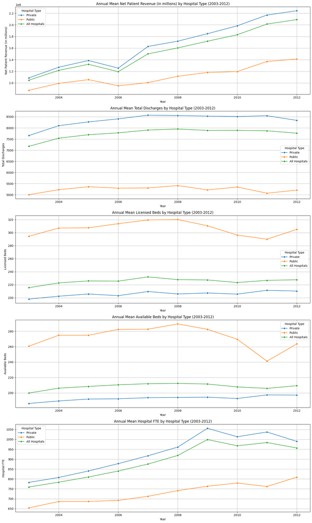

```python
metrics = ['net_pt_rev', 'dis_tot', 'bed_lic', 'bed_avl', 'hosp_fte']
metric_titles = {
    'net_pt_rev': 'Net Patient Revenue (in millions)',
    'dis_tot': 'Total Discharges',
    'bed_lic': 'Licensed Beds',
    'bed_avl': 'Available Beds',
    'hosp_fte': 'Hospital FTE'
}

plt.figure(figsize=(15, 25))

for i, metric in enumerate(metrics):
    plt.subplot(len(metrics), 1, i + 1)
    sns.lineplot(
        data=plot_df,
        x='year',
        y=metric,
        hue='hospital_type',
        marker='o'
    )
    plt.title(f'Annual Mean {metric_titles[metric]} by Hospital Type (2003-2012)')
    plt.xlabel('Year')
    plt.ylabel(metric_titles[metric])
    plt.grid(True)
    plt.legend(title='Hospital Type')

plt.tight_layout()
plt.show()
```

**Figure 1, Net Patient Revenue:**

**Figure 2: Total Discharges**

The trend in total discharges is relatively flat compared to net patient revenue. Private hospitals experience a slight decline in discharges from 2007 to 2010, while public hospitals show a modest increase around 2008.

**Figure 3: Licensed Beds**

Public hospitals have significantly more licensed beds than private hospitals, and their bed capacity increased during the financial crisis period (2007–2008). In contrast, private hospitals saw a small increase in licensed beds in 2007 followed by a decline in 2008. Overall, this suggests that public hospitals bore a larger share of the service burden during the financial crisis compared to private hospitals.

**Figure 4: Avaliable Beds**

The trend in available beds mirrors that of licensed beds during the financial crisis period. However, after the shock, the number of available beds in public hospitals declines rapidly and continues to fall until around 2011.

**Figure 5: Hospital FTE**

Next, I want to identify the hospital closures and examine what are the control types of these closed hospitals.

```python
closed_hospitals_by_year = {}

for year in range(2003, 2012):
    fac_no_current_year = set(merged_df[merged_df['year'] == year]['fac_no'].dropna().unique())
    fac_no_next_year = set(merged_df[merged_df['year'] == year + 1]['fac_no'].dropna().unique())

    # Hospitals that closed are those present in the current year but not in the next year
    closed_fac_no = fac_no_current_year - fac_no_next_year

    transition_key = f"{year}-{year+1}"
    closed_hospitals_by_year[transition_key] = list(closed_fac_no)

print("Hospital closures identified and stored in 'closed_hospitals_by_year' dictionary.")
```

```
Hospital closures identified and stored in 'closed_hospitals_by_year' dictionary.
```

```python
closures_data = []

for transition_key, closed_fac_nos in closed_hospitals_by_year.items():
    current_year = int(transition_key.split('-')[0])

    for fac_no_closed in closed_fac_nos:

        fac_no_closed_numeric = float(fac_no_closed)

        control_type_series = merged_df[
            (merged_df['year'] == current_year) &
            (merged_df['fac_no'] == fac_no_closed_numeric)
        ]['type_cntrl']


        if not control_type_series.empty:
            control_type = control_type_series.iloc[0]
        else:
            control_type = 'Unknown'

        closures_data.append({
            'Transition Year': transition_key,
            'fac_no': fac_no_closed,
            'type_cntrl': control_type
        })

closures_df = pd.DataFrame(closures_data)

print("Closures DataFrame created successfully.")
display(closures_df.head())
print("\nInformation about closures_df:")
closures_df.info()
```

```
Closures DataFrame created successfully.
```

|  | Transition Year | fac_no | type_cntrl |
| --- | --- | --- | --- |
| 0 | 2003-2004 | 106,400,512.00 | city/county |
| 1 | 2003-2004 | 106,014,113.00 | investor |
| 2 | 2003-2004 | 106,510,882.00 | non-profit |
| 3 | 2003-2004 | 106,370,721.00 | investor |
| 4 | 2003-2004 | 106,190,691.00 | non-profit |

```
Information about closures_df:
<class 'pandas.core.frame.DataFrame'>
RangeIndex: 66 entries, 0 to 65
Data columns (total 3 columns):
 #   Column           Non-Null Count  Dtype
---  ------           --------------  -----
 0   Transition Year  66 non-null     object
 1   fac_no           66 non-null     float64
 2   type_cntrl       66 non-null     object
dtypes: float64(1), object(2)
memory usage: 1.7+ KB
```

```python
closures_by_type_year = closures_df.groupby(['Transition Year', 'type_cntrl']).size().unstack(fill_value=0)
closures_by_type_year['Total Closures'] = closures_by_type_year.sum(axis=1)

print("Aggregated closures by year and control type:")
display(closures_by_type_year)
```

```
Aggregated closures by year and control type:
```

| type_cntrl Transition Year | city/county | district | investor | non-profit | state | Total Closures |
| --- | --- | --- | --- | --- | --- | --- |
| 2003-2004 | 3 | 1 | 8 | 5 | 0 | 17 |
| 2004-2005 | 1 | 0 | 3 | 6 | 0 | 10 |
| 2005-2006 | 0 | 0 | 2 | 6 | 0 | 8 |
| 2006-2007 | 0 | 2 | 2 | 0 | 0 | 4 |
| 2007-2008 | 2 | 0 | 2 | 4 | 0 | 8 |
| 2008-2009 | 0 | 0 | 1 | 1 | 0 | 2 |
| 2009-2010 | 0 | 0 | 4 | 3 | 2 | 9 |
| 2010-2011 | 0 | 1 | 3 | 2 | 0 | 6 |
| 2011-2012 | 1 | 0 | 1 | 0 | 0 | 2 |

Between 2003 and 2012, a total of 66 hospitals were identified as closed, based on their presence in one year and absence in the following year.

The highest number of closures occurred in 2003, when 17 hospitals closed. During the Great Recession, the 2007–2008 transition also saw a relatively high number of closures, with 8 hospitals closing. While only 2 hospitals closed in 2008, closures increased to 9 in 2009.

It is reasonable that more private hospitals (both non-profit and investor-owned) closed during the Great Recession. Public hospitals, which typically rely on government funding, are generally more stable and better able to withstand financial pressures compared to private hospitals.

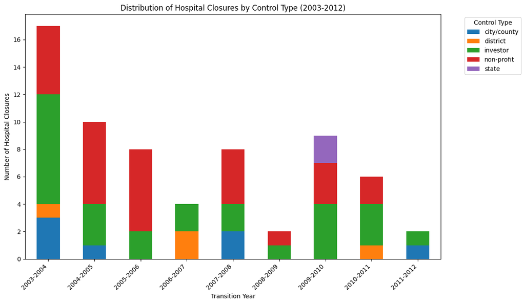

```python
plot_columns = [col for col in closures_by_type_year.columns if col != 'Total Closures']

closures_by_type_year[plot_columns].plot(kind='bar', stacked=True, figsize=(12, 7))

plt.title('Distribution of Hospital Closures by Control Type (2003-2012)')
plt.xlabel('Transition Year')
plt.ylabel('Number of Hospital Closures')

plt.xticks(rotation=45, ha='right')

plt.legend(title='Control Type', bbox_to_anchor=(1.05, 1), loc='upper left')

plt.tight_layout()

plt.show()
```

# **Two-way fixed effects model**

$Y_{it}=\alpha_i +\lambda_{t}+\beta Recession_t+\gamma X_{it}+ϵ_{it}$

$Y_{it}$: Key outcomes: net patient revenue, total discharges, hospital FTEs.

$\alpha_i$: Hospital fixed effects

$ Recession_t$: Recession indicator, it is a binary variable indicating whether year t is during the Great Recession.

$X_{it}$: Control variables, including total licensed beds and total avaliable beds.

$ϵ_{it}$: Error term.

```python
merged_util_df = merged_util_df.rename(columns={'OSHPD_ID': 'fac_no'})
final_merged_df = pd.merge(merged_df, merged_util_df, on=['fac_no', 'year'], how='outer')

new_column_order = [
    'fac_no', 'fac_name', 'type_cntrl','county', 'year',
    'net_pt_rev', 'dis_tot', 'bed_lic', 'bed_avl', 'hosp_fte'
]
final_merged_df = final_merged_df[new_column_order].copy()

# Initial dropna
initial_rows = final_merged_df.shape[0]
final_merged_df = final_merged_df.dropna()
rows_after_drop = final_merged_df.shape[0]
print(f"Initial number of rows: {initial_rows}")
print(f"Number of rows after dropping NaNs: {rows_after_drop}")
print(f"Number of rows dropped: {initial_rows - rows_after_drop}")

# Numeric conversions and dropna for specific columns
numeric_cols = ['net_pt_rev', 'dis_tot', 'bed_lic', 'bed_avl', 'hosp_fte']
for col in numeric_cols:
    if col in final_merged_df.columns:
        final_merged_df[col] = pd.to_numeric(final_merged_df[col], errors='coerce')

initial_rows_before_recheck = final_merged_df.shape[0]
final_merged_df = final_merged_df.dropna(subset=numeric_cols)
rows_after_recheck_drop = final_merged_df.shape[0]

print(f"Rows before rechecking and dropping NaNs in numeric columns: {initial_rows_before_recheck}")
print(f"Rows after rechecking and dropping NaNs in numeric columns: {rows_after_recheck_drop}")
print(f"Rows dropped during recheck of numeric columns: {initial_rows_before_recheck - rows_after_recheck_drop}")

# Set MultiIndex
final_merged_df = final_merged_df.set_index(['fac_no', 'year'])

# Create Recession_t variable
final_merged_df['Recession_t'] = final_merged_df.index.get_level_values('year').isin([2008]).astype(int)

display(final_merged_df.head())
dependent_variables = ['net_pt_rev', 'dis_tot', 'hosp_fte']
results = {}

for dep_var in dependent_variables:
    formula = f'{dep_var} ~ Recession_t + bed_lic + bed_avl + EntityEffects'

    model = PanelOLS.from_formula(formula, data=final_merged_df)
    fit_results = model.fit()
    results[dep_var] = fit_results

    print(f'\nRegression Results for: {dep_var}')
    print(fit_results)
```

```
Regression Results for: net_pt_rev
                          PanelOLS Estimation Summary
================================================================================
Dep. Variable:             net_pt_rev   R-squared:                        0.0059
Estimator:                   PanelOLS   R-squared (Between):              0.1640
No. Observations:                4581   R-squared (Within):               0.0059
Date:                Fri, Dec 12 2025   R-squared (Overall):              0.1470
Time:                        05:41:29   Log-likelihood                -9.232e+04
Cov. Estimator:            Unadjusted
                                        F-statistic:                      8.0776
Entities:                         501   P-value                           0.0000
Avg Obs:                       9.1437   Distribution:                  F(3,4077)
Min Obs:                       1.0000
Max Obs:                       12.000   F-statistic (robust):             8.0776
                                        P-value                           0.0000
Time periods:                      10   Distribution:                  F(3,4077)
Avg Obs:                       458.10
Min Obs:                       447.00
Max Obs:                       512.00

                              Parameter Estimates
===============================================================================
             Parameter  Std. Err.     T-stat    P-value    Lower CI    Upper CI
-------------------------------------------------------------------------------
Recession_t   4.43e+06  7.209e+06     0.6145     0.5389  -9.704e+06   1.856e+07
bed_lic      1.666e+05  6.461e+04     2.5789     0.0099   3.995e+04   2.933e+05
bed_avl      1.592e+05  6.831e+04     2.3309     0.0198    2.53e+04   2.932e+05
===============================================================================

F-test for Poolability: 50.708
P-value: 0.0000
Distribution: F(500,4077)

Included effects: Entity

Regression Results for: dis_tot
                          PanelOLS Estimation Summary
================================================================================
Dep. Variable:                dis_tot   R-squared:                        0.1096
Estimator:                   PanelOLS   R-squared (Between):              0.4191
```

[output cut: 49 more lines]

```

                              Parameter Estimates
===============================================================================
             Parameter  Std. Err.     T-stat    P-value    Lower CI    Upper CI
-------------------------------------------------------------------------------
Recession_t     26.943     11.948     2.2550     0.0242      3.5177      50.368
bed_lic         0.4172     0.1071     3.8956     0.0001      0.2072      0.6271
bed_avl         1.0442     0.1132     9.2223     0.0000      0.8222      1.2661
===============================================================================

F-test for Poolability: 131.38
P-value: 0.0000
Distribution: F(500,4077)

Included effects: Entity
```

The following articles are closely related to the topic examined in this project.

[Healthcare jobs and the Great Recession](https://www.bls.gov/opub/mlr/2018/article/healthcare-jobs-and-the-great-recession.htm)

[Are U.S. Hospitals Still “Recession-proof”?](https://www.nejm.org/doi/full/10.1056/NEJMp2018846)

[Health Spending Growth: The Effects of the Great Recession](https://www.brookings.edu/articles/health-spending-growth-the-effects-of-the-great-recession/)

```python
%%shell
ls "/content/drive/MyDrive/Colab Notebooks/milestone1CL .ipynb"
```

```
'/content/drive/MyDrive/Colab Notebooks/milestone1CL .ipynb'
```

```python
%%shell

jupyter nbconvert --to html "/content/drive/MyDrive/Colab Notebooks/milestone1CL .ipynb"
```

```
[NbConvertApp] Converting notebook /content/drive/MyDrive/Colab Notebooks/milestone1CL .ipynb to html
[NbConvertApp] WARNING | Alternative text is missing on 2 image(s).
[NbConvertApp] Writing 919967 bytes to /content/drive/MyDrive/Colab Notebooks/milestone1CL .html
```